# convex_hull_matplotlib

I chose to create convex hulls on the US Cities dataset in the Bridges package and visualizing via matplotlib. I have created the brute force and divide and conquer algorithms which use the same helper methods to help condense the code.

This code's merge hull is not working with tightly clustered points and I haven't figure out why.

```python
from bridges.data_src_dependent import data_source
from math import atan2
from sympy import Rational

import matplotlib.pyplot as plt
import time

EPSILON = 1e-9 # helps with any floating point errors
```

Here are the functions for visualizing the data

```python
# This draws all the points the graph with matplotlib
def show_graph(cities):
    points = [(city.lon, city.lat) for city in cities]
    lats = [point[1] for point in points]
    lons = [point[0] for point in points]

    plt.figure(figsize=(10, 8))
    plt.scatter(lons, lats, s=1, color='red', alpha=1)

    plt.xlabel("Longitude")
    plt.ylabel("Latitude")
    plt.title("Cities Plotted by Latitude and Longitude")

    plt.grid(True, alpha=1)
    plt.show()


def number_of_hull_cities(cities, algorithm_name):
    print(f"The number of hull cities is: {len(cities)} for algorithm {algorithm_name}.")


# This draws the convex hull and the data points on the graph without labels
def draw_convex_hull(cities, hull, algorithm_name):
    points = [(city.lon, city.lat) for city in cities]
    lats = [point[1] for point in points]
    lons = [point[0] for point in points]

    plt.figure(figsize=(10, 8))
    plt.scatter(lons, lats, s=1, color="red", label="Cities", alpha=0.5)

    hull = sort_hull_cities(hull)

    hull_lats = [city.lat for city in hull + [hull[0]]]
    hull_lons = [city.lon for city in hull + [hull[0]]]
    plt.plot(hull_lons, hull_lats, linewidth=2, color="blue", label="Convex Hull", alpha=0.5)

    plt.xlabel("Longitude")
    plt.ylabel("Latitude")
    plt.title(f"{algorithm_name} Convex Hull of Cities")
    plt.legend()
    plt.show()

    number_of_hull_cities(hull, algorithm_name)


# This draws the convex hull and the data points on the graph with city name, city state labels
def draw_convex_hull_coordinates(cities, hull, algorithm_name):
    points = [(city.lon, city.lat) for city in cities]
    lats = [point[1] for point in points]
    lons = [point[0] for point in points]

    plt.figure(figsize=(10, 8))
    plt.scatter(lons, lats, s=1, color="red", label="Cities", alpha=0.5)

    hull = sort_hull_cities(hull)

    hull_lats = [city.lat for city in hull + [hull[0]]]
    hull_lons = [city.lon for city in hull + [hull[0]]]
    plt.plot(hull_lons, hull_lats, linewidth=2, color="blue", label="Convex Hull", alpha=0.5)

    for i, city in enumerate(hull):
        plt.text(city.lon, city.lat, f"({city.lon:.2f}, {city.lat:.2f})", fontsize=8, color="green")

    plt.xlabel("Longitude")
    plt.ylabel("Latitude")
    plt.title(f"{algorithm_name} Convex Hull of Cities")
    plt.legend()
    plt.show()

    number_of_hull_cities(hull, algorithm_name)


# This draws the convex hull and the data points on the graph with coordinate labels
def draw_convex_hull_names(cities, hull, algorithm_name):
    points = [(city.lon, city.lat) for city in cities]
    lats = [point[1] for point in points]
    lons = [point[0] for point in points]

    plt.figure(figsize=(10, 8))
    plt.scatter(lons, lats, s=1, color="red", label="Cities", alpha=0.5)

    hull = sort_hull_cities(hull)

    hull_lats = [city.lat for city in hull + [hull[0]]]
    hull_lons = [city.lon for city in hull + [hull[0]]]
    plt.plot(hull_lons, hull_lats, linewidth=2, color="blue", label="Convex Hull", alpha=0.5)

    for i, city in enumerate(hull):
        plt.text(city.lon, city.lat, f"{city.city}, {city.state}", fontsize=8, color="green")

    plt.xlabel("Longitude")
    plt.ylabel("Latitude")
    plt.title(f"{algorithm_name} Convex Hull of Cities")
    plt.legend()
    plt.show()

    number_of_hull_cities(hull, algorithm_name)
```

Here are the functions that make the code interactive via the main method

```python
# Helper function for the construction of the hull
def sort_hull_cities(hull):
    centroid_lat = sum(city.lat for city in hull) / len(hull)
    centroid_lon = sum(city.lon for city in hull) / len(hull)

    def angle_from_centroid(city):
        lat, lon = city.lat, city.lon
        return atan2(lat - centroid_lat, lon - centroid_lon)

    return sorted(hull, key=angle_from_centroid)
```

```python
def choose_cities(choice):
    us_cities = data_source.get_us_cities_data()

    match choice:
        case 1:
            return us_cities
        case 2:
            return [c for c in us_cities if c.state not in ("AK", "HI")]
        case 3:
            east_coast_states = {
                "ME", "NH", "MA", "RI", "CT", "NY", "NJ",
                "DE", "MD", "VA", "NC", "SC", "GA", "FL"
            }
            west_coast_states = {"CA", "OR", "WA"}

            coast_name = input("East or west coast? Example: east ").strip().lower()

            if coast_name == "east":
                return [c for c in us_cities if c.state in east_coast_states]
            elif coast_name == "west":
                return [c for c in us_cities if c.state in west_coast_states]
            else:
                print("Could not parse input. Please use 'east' or 'west'.")
                return
        case 4:
            state_abbreviation = input("Enter the state abbreviation (e.g., 'NC' for North Carolina): ").strip().upper()
            state_cities = [c for c in us_cities if c.state == state_abbreviation]

            if not state_cities:
                print(f"No cities found for state: {state_abbreviation}.")
                return
            return state_cities
        case 5:
            type_input = input("Population above or below population_number (e.g., 'above 1000000' or 'below 50000'): ").strip().lower()

            try:
                direction, number = type_input.split()
                number = int(number)
            except ValueError:
                print("Could not parse input. Please use 'above <number>' or 'below <number>'.")
                return

            if direction == "above":
                return [c for c in us_cities if c.population > number]
            elif direction == "below":
                return [c for c in us_cities if c.population < number]
            else:
                print("Invalid direction. Please use 'above' or 'below'.")
                return
        case _:
            print("Invalid choice. Please select a valid option.")
            return
```

Here are the functions that all the algorithms use

There are the two ways we can calculate where a point is in relation to two other points

1. Using the slope and intercept between two points and finding if the third point satisfies the equation (aka the position of the point)
2. Using the determinant of the matrix (which constructs a triangle via all three points) which then tells us the relation between all three points
   1. Positive: A, B, and C are counterclockwise
   2. Negative: A, B, and C are clockwise
   3. Zero: A, B, and C are co-linear (aka forming a line)

```python
def get_slope(city1, city2):
    if abs(city1.lon - city2.lon) < EPSILON:
        slope = float('inf')
    else:
        slope = (city2.lat - city1.lat) / (city2.lon - city1.lon)

    intercept = city1.lat - slope * city1.lon

    return slope, intercept


def get_point_placement_on_slope(slope, intercept, x, city):
    # y = mx + b rewritten to _ = mx + b - y
    if slope is float('inf'):
        return city.lon - x

    return slope * city.lon + intercept - city.lat


def cross_product_determinant(city1, city2, city3):
    lon1, lat1 = city1.lon, city1.lat
    lon2, lat2 = city2.lon, city2.lat
    lon3, lat3 = city3.lon, city3.lat

    return (lon2 - lon1) * (lat3 - lat1) - (lat2 - lat1) * (lon3 - lon1)

def cross_product_simple(city1, city2, city3):
    lon1, lat1 = Rational(city1.lon), Rational(city1.lat)
    lon2, lat2 = Rational(city2.lon), Rational(city2.lat)
    lon3, lat3 = Rational(city3.lon), Rational(city3.lat)

    value = (lon2 - lon1) * (lat3 - lat1) - (lat2 - lat1) * (lon3 - lon1)

    if value == 0:
        return 0
    return 1 if value > 0 else -1
```

Here is the brute force code which can use either the determinant or slope for calculating the cross product

```python
def brute_force_convex_hull_slope(cities):
    n = len(cities)
    if n < 3: # all 2D shapes must have at least 3 points
        return cities

    hull = set()

    for i in range(n):
        for j in range(i+1, n):
            city1, city2 = cities[i], cities[j]
            x = city1.lon
            left_set, right_set = False, False

            try: # Catching undefined slopes
                slope, intercept = get_slope(city1, city2)
            except Exception as e:
                print(f"Error calculating slope between {city1} and {city2}: {e}")
                continue

            for k in range(n):
                if k == i or k == j:
                    continue

                city3 = cities[k]
                cross = get_point_placement_on_slope(slope, intercept, x, city3)

                if cross > EPSILON:
                    left_set = True
                if cross < EPSILON:
                    right_set = True

                if left_set and right_set:
                    break

            if (not left_set and right_set) or (not right_set and left_set):
                hull.add(city1)
                hull.add(city2)

    return list(hull)


def brute_force_convex_hull_determinant(cities):
    n = len(cities)
    if n < 3: # all 2D shapes must have at least 3 points
        return cities

    hull = set()

    for i in range(n):
        for j in range(i+1, n):
            city1, city2 = cities[i], cities[j]
            left_set, right_set = False, False

            for k in range(n):
                if k == i or k == j:
                    continue

                city3 = cities[k]
                cross = cross_product_determinant(city1, city2, city3)

                if cross > EPSILON:
                    left_set = True
                if cross < EPSILON:
                    right_set = True

                if left_set and right_set:
                    break

            if (not left_set and right_set) or (not right_set and left_set):
                hull.add(city1)
                hull.add(city2)

    return list(hull)
```

Here is a divide and conquer for a quick hull

```python
def distance_from_line(city1, city2, city3):
    lon1, lat1 = Rational(city1.lon), Rational(city1.lat)
    lon2, lat2 = Rational(city2.lon), Rational(city2.lat)
    lon3, lat3 = Rational(city3.lon), Rational(city3.lat)

    return abs((lon2 - lon1) * (lat3 - lat1) - (lat2 - lat1) * (lon3 - lon1))


def find_farthest_city(city1, city2, cities):
    max_distance = -1
    farthest_city = None
    for city3 in cities:
        distance = distance_from_line(city1, city2, city3)
        if distance > max_distance:
            max_distance = distance
            farthest_city = city3
    return farthest_city


def quickhull_rec(city1, city2, cities):
    if not cities:
        return []

    farthest_city = find_farthest_city(city1, city2, cities)
    hull = [farthest_city]

    left_set1 = [city for city in cities if cross_product_simple(city1, farthest_city, city) > 0]
    left_set2 = [city for city in cities if cross_product_simple(farthest_city, city2, city) > 0]

    hull += quickhull_rec(city1, farthest_city, left_set1)
    hull += quickhull_rec(farthest_city, city2, left_set2)

    return hull


def divide_and_conquer_quick_convex_hull(cities):
    cities = sort(cities)

    city1, city2 = cities[0], cities[-1]

    upper_set = [city for city in cities if cross_product_determinant(city1, city2, city) > 0]
    lower_set = [city for city in cities if cross_product_determinant(city2, city1, city) > 0]

    upper_hull = quickhull_rec(city1, city2, upper_set)
    lower_hull = quickhull_rec(city2, city1, lower_set)

    return [city1] + upper_hull + [city2] + lower_hull
```

Here is a divide and conquer for a merge hull

This has a bug with closely clustered cities.

```python
def sort(cities):
    return sorted(cities, key=lambda city: (Rational(city.lon), Rational(city.lat)))


def is_close_to_zero(value):
    return abs(value) < EPSILON


def distance_squared(p1, p2):
    return (p1.lon - p2.lon)**2 + (p1.lat - p2.lat)**2


def find_upper_tangent(left_hull, right_hull, right_most_left, left_most_right):
    count = 0
    i, j = right_most_left, left_most_right
    while True:
        moved = False
        # Move `i` clockwise on the left hull
        while True:
            cross = cross_product_simple(right_hull[j], left_hull[i], left_hull[(i + 1) % len(left_hull)])
            if cross < -EPSILON:
                i = (i + 1) % len(left_hull)
                moved = True
                count += 1
            elif is_close_to_zero(cross):
                # Handle collinear points by checking distances
                next_i = (i + 1) % len(left_hull)
                if distance_squared(right_hull[j], left_hull[next_i]) > distance_squared(right_hull[j], left_hull[i]):
                    i = next_i
                    moved = True
                else:
                    break
            else:
                break
            if count > 1000:
                print("help")
                break

        count = 0
        # Move `j` counterclockwise on the right hull
        while True:
            cross = cross_product_simple(left_hull[i], right_hull[j], right_hull[(j - 1) % len(right_hull)])
            if cross > EPSILON:
                j = (j - 1) % len(right_hull)
                moved = True
                count += 1
            elif is_close_to_zero(cross):
                # Handle collinear points by checking distances
                prev_j = (j - 1) % len(right_hull)
                if distance_squared(left_hull[i], right_hull[prev_j]) > distance_squared(left_hull[i], right_hull[j]):
                    j = prev_j
                    moved = True
                else:
                    break
            else:
                break
            if count > 1000:
                print("help")
                break

        if not moved:
            break
    return i, j


def find_lower_tangent(left_hull, right_hull, right_most_left, left_most_right):
    count = 0
    i, j = right_most_left, left_most_right
    while True:
        moved = False
        # Move `j` clockwise on the right hull
        while True:
            cross = cross_product_simple(left_hull[i], right_hull[j], right_hull[(j + 1) % len(right_hull)])
            if cross < -EPSILON:
                j = (j + 1) % len(right_hull)
                moved = True
                count += 1
            elif is_close_to_zero(cross):
                # Handle collinear points by checking distances
                next_j = (j + 1) % len(right_hull)
                if distance_squared(left_hull[i], right_hull[next_j]) > distance_squared(left_hull[i], right_hull[j]):
                    j = next_j
                    moved = True
                else:
                    break
            else:
                break
            if count > 1000:
                print("help")
                break

        count = 0
        # Move `i` counterclockwise on the left hull
        while True:
            cross = cross_product_simple(right_hull[j], left_hull[i], left_hull[(i - 1) % len(left_hull)])
            if cross > EPSILON:
                i = (i - 1) % len(left_hull)
                moved = True
                count += 1
            elif is_close_to_zero(cross):
                # Handle collinear points by checking distances
                prev_i = (i - 1) % len(left_hull)
                if distance_squared(right_hull[j], left_hull[prev_i]) > distance_squared(right_hull[j], left_hull[i]):
                    i = prev_i
                    moved = True
                else:
                    break
            else:
                break
            if count > 1000:
                print("help")
                break

        if not moved:
            break
    return i, j


def merge_hulls(left_hull, right_hull):
    len_left = len(left_hull)
    len_right = len(right_hull)

    # Find rightmost point of left hull and leftmost point of right hull
    right_most_left = max(range(len_left), key=lambda i: Rational(left_hull[i].lon))
    left_most_right = min(range(len_right), key=lambda i: Rational(right_hull[i].lon))

    upper_left, upper_right = find_upper_tangent(left_hull, right_hull, right_most_left, left_most_right)
    lower_left, lower_right = find_lower_tangent(left_hull, right_hull, right_most_left, left_most_right)

    # Merge hulls, left and right side
    merged_hull = []

    # Traverse upper hull from upper_left to lower_left
    index = upper_left
    while True:
        merged_hull.append(left_hull[index])
        if index == lower_left:
            break
        index = (index + 1) % len_left

    # Traverse lower hull from lower_right to upper_right
    index = lower_right
    while True:
        merged_hull.append(right_hull[index])
        if index == upper_right:
            break
        index = (index + 1) % len_right

    return merged_hull


def divide_and_conquer_merge_convex_hull(cities):
    if len(cities) < 3:
        return sort(cities)

    sorted_cities = sort(cities)
    mid = len(cities) // 2

    left = sorted_cities[:mid]
    right = sorted_cities[mid:]

    left_hull = divide_and_conquer_merge_convex_hull(left)
    right_hull = divide_and_conquer_merge_convex_hull(right)

    return merge_hulls(left_hull, right_hull)
```

Here is the main method code which will run and show all the convex hulls on your choosen section of the data from Bridges

```
1656
	Execution time for prep work was: 0.773784 seconds
```

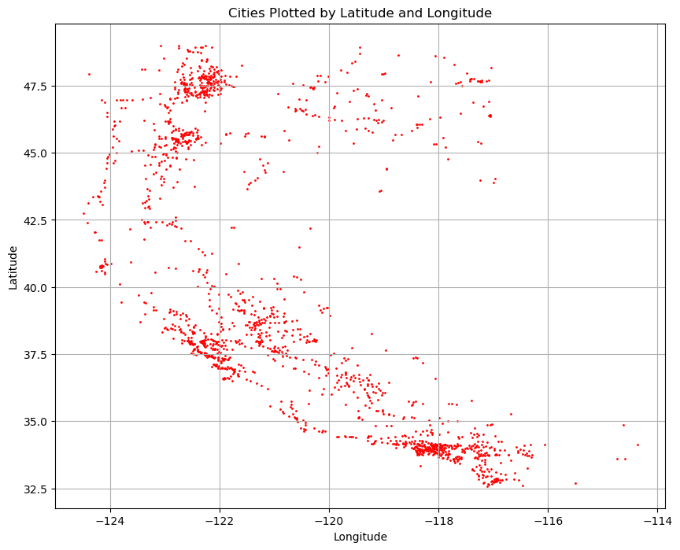

```
	Execution time for drawing points was: 0.073361 seconds
```

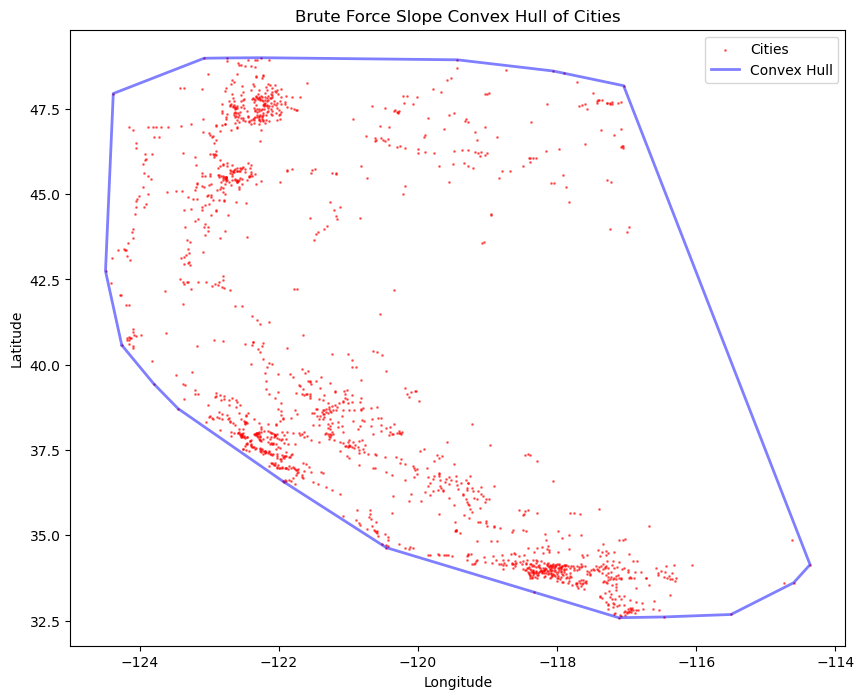

```
The number of hull cities is: 18 for algorithm Brute Force Slope.
	Execution time for brute force with slope convex hull was: 21.709151 seconds
```

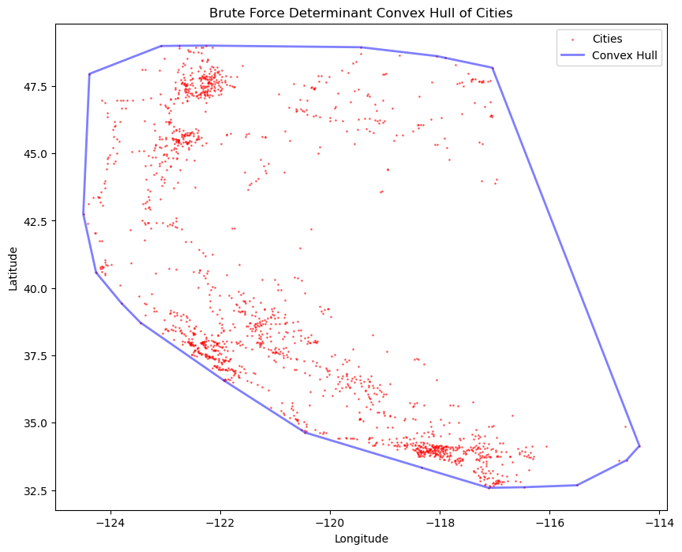

```
The number of hull cities is: 18 for algorithm Brute Force Determinant.
	Execution time for brute force with determinant convex hull was: 30.765122 seconds
```

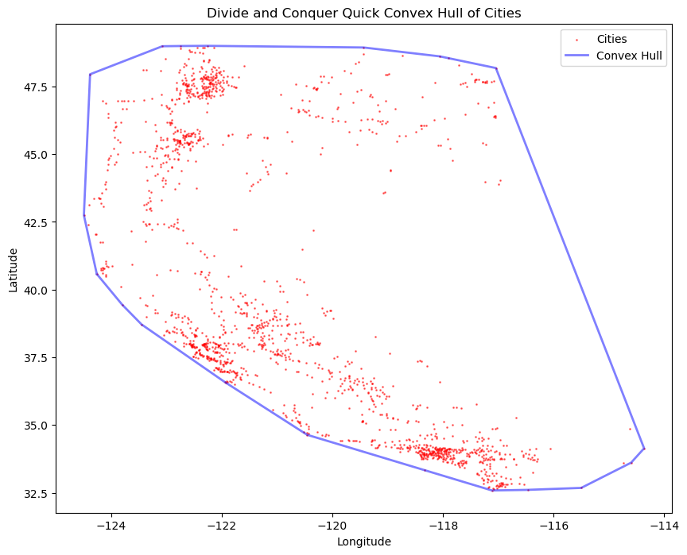

```
The number of hull cities is: 18 for algorithm Divide and Conquer Quick.
	Execution time for divide and conquer convex hull was: 0.277751 seconds
```

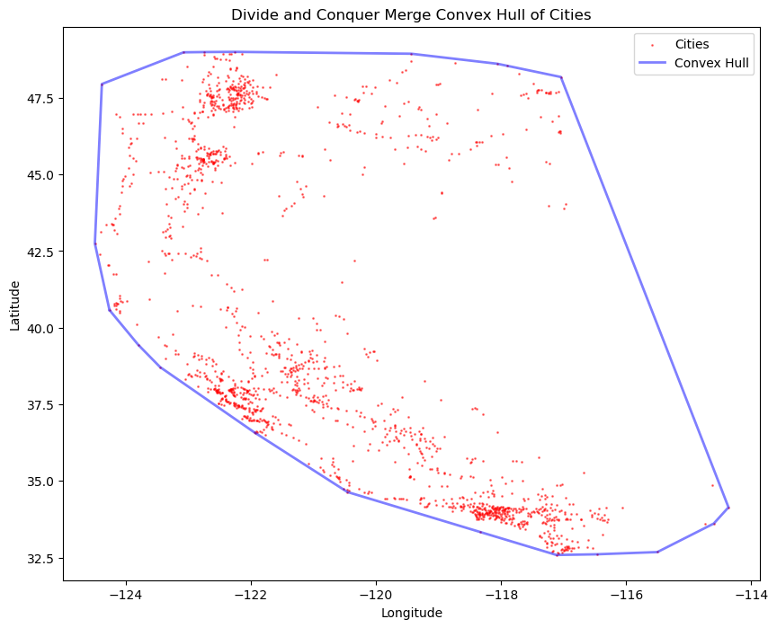

```
The number of hull cities is: 18 for algorithm Divide and Conquer Merge.
	Execution time for divide and conquer convex hull was: 0.333385 seconds

Execution time for all was: 53.932595 seconds
```

```python
def main():
    start_time = time.time()

    '''print("Choose which cities to graph:")
    print("1. All cities")
    print("2. Continental US cities")
    print("3. East or West Coast cities")
    print("4. Cities in a single state")
    print("5. Cities filtered by population")'''

    '''try:
        choice = int(input("Enter your choice (1-5): ").strip())
    except ValueError:
        print("Invalid input. Please enter a number between 1 and 5.")
        return

    cities = choose_cities(choice)'''

    us_cities = data_source.get_us_cities_data()

    #cities = [c for c in us_cities if c.state == "UT"] # Execution time for all was: 1.342935 seconds | 12

    #cities = [c for c in us_cities if c.state == "CA"] # Execution time for all was: 2.879586 seconds | 15

    cities = [c for c in us_cities if c.state in {"CA", "OR", "WA"}] # Execution time: 54.299286 seconds | 18

    print(len(cities))

    sorting_time = time.time()
    prework_time = sorting_time - start_time
    print(f"\tExecution time for prep work was: {prework_time:.6f} seconds")

    if cities:
        start_graph_time = time.time()
        show_graph(cities)
        end_graph_time = time.time()
        print(f"\tExecution time for drawing points was: {(end_graph_time-start_graph_time):.6f} seconds")

        start_graph_time = time.time()
        draw_convex_hull(cities, brute_force_convex_hull_slope(cities), "Brute Force Slope")
        end_graph_time = time.time()
        print(f"\tExecution time for brute force with slope convex hull was: {(end_graph_time - start_graph_time):.6f} seconds")

        start_graph_time = time.time()
        draw_convex_hull(cities, brute_force_convex_hull_determinant(cities), "Brute Force Determinant")
        end_graph_time = time.time()
        print(f"\tExecution time for brute force with determinant convex hull was: {(end_graph_time - start_graph_time):.6f} seconds")

        start_graph_time = time.time()
        draw_convex_hull(cities, divide_and_conquer_quick_convex_hull(cities), "Divide and Conquer Quick")
        end_graph_time = time.time()
        print(f"\tExecution time for divide and conquer convex hull was: {(end_graph_time - start_graph_time):.6f} seconds")

        start_graph_time = time.time()
        draw_convex_hull(cities, divide_and_conquer_merge_convex_hull(cities), "Divide and Conquer Merge")
        end_graph_time = time.time()
        print(f"\tExecution time for divide and conquer convex hull was: {(end_graph_time - start_graph_time):.6f} seconds")

    else:
        print("No cities to display.")

    print()

    end_time = time.time()
    execution_time = end_time - start_time
    print(f"Execution time for all was: {execution_time:.6f} seconds")


# Run the main function
if __name__ == "__main__":
    main()
```